# The Analytics Edge

Na Sai

March 13, 2015

# Assignment1

## An analytical detective

Crime is an international concern, but it is documented and handled in very different ways in different countries. In the United States, violent crimes and property crimes are recorded by the Federal Bureau of Investigation (FBI). Additionally, each city documents crime, and some cities release data regarding crime rates. The city of Chicago, Illinois releases crime data from 2001 onward online.

There are two main types of crimes: violent crimes, and property crimes. In this problem, we’ll focus on one specific type of property crime, called “motor vehicle theft” (sometimes referred to as grand theft auto). This is the act of stealing, or attempting to steal, a car. In this problem, we’ll use some basic data analysis in R to understand the motor vehicle thefts in Chicago.

- P1 Loading the data

```r
rm(list=ls())
mvt<-read.csv("mvtWeek1.csv")
str(mvt)
```

```
## 'data.frame':    191641 obs. of  11 variables:
##  $ ID                 : int  8951354 8951141 8952745 8952223 8951608 8950793 8950760 8951611 8951802 8950706 ...
##  $ Date               : Factor w/ 131680 levels "1/1/01 0:01",..: 42824 42823 42823 42823 42822 42821 42820 42819 42817 42816 ...
##  $ LocationDescription: Factor w/ 78 levels "ABANDONED BUILDING",..: 72 72 62 72 72 72 72 72 72 72 ...
##  $ Arrest             : logi  FALSE FALSE FALSE FALSE FALSE TRUE ...
##  $ Domestic           : logi  FALSE FALSE FALSE FALSE FALSE FALSE ...
##  $ Beat               : int  623 1213 1622 724 211 2521 423 231 1021 1215 ...
##  $ District           : int  6 12 16 7 2 25 4 2 10 12 ...
##  $ CommunityArea      : int  69 24 11 67 35 19 48 40 29 24 ...
##  $ Year               : int  2012 2012 2012 2012 2012 2012 2012 2012 2012 2012 ...
##  $ Latitude           : num  41.8 41.9 42 41.8 41.8 ...
##  $ Longitude          : num  -87.6 -87.7 -87.8 -87.7 -87.6 ...
```

```r
summary(mvt)
```

```
##        ID                      Date
##  Min.   :1310022   5/16/08 0:00  :    11
##  1st Qu.:2832144   10/17/01 22:00:    10
##  Median :4762956   4/13/04 21:00 :    10
##  Mean   :4968629   9/17/05 22:00 :    10
##  3rd Qu.:7201878   10/12/01 22:00:     9
##  Max.   :9181151   10/13/01 22:00:     9
##                    (Other)       :191582
##                      LocationDescription   Arrest         Domestic
##  STREET                        :156564   Mode :logical   Mode :logical
##  PARKING LOT/GARAGE(NON.RESID.): 14852   FALSE:176105    FALSE:191226
##  OTHER                         :  4573   TRUE :15536     TRUE :415
##  ALLEY                         :  2308   NA's :0         NA's :0
##  GAS STATION                   :  2111
##  DRIVEWAY - RESIDENTIAL        :  1675
##  (Other)                       :  9558
##       Beat         District     CommunityArea        Year
##  Min.   : 111   Min.   : 1.00   Min.   : 0      Min.   :2001
##  1st Qu.: 722   1st Qu.: 6.00   1st Qu.:22      1st Qu.:2003
##  Median :1121   Median :10.00   Median :32      Median :2006
##  Mean   :1259   Mean   :11.82   Mean   :38      Mean   :2006
##  3rd Qu.:1733   3rd Qu.:17.00   3rd Qu.:60      3rd Qu.:2009
##  Max.   :2535   Max.   :31.00   Max.   :77      Max.   :2012
##                 NA's   :43056   NA's   :24616
##     Latitude       Longitude
##  Min.   :41.64   Min.   :-87.93
##  1st Qu.:41.77   1st Qu.:-87.72
##  Median :41.85   Median :-87.68
##  Mean   :41.84   Mean   :-87.68
##  3rd Qu.:41.92   3rd Qu.:-87.64
##  Max.   :42.02   Max.   :-87.52
##  NA's   :2276    NA's   :2276
```

```r
attach(mvt)
max(ID)
```

```
## [1] 9181151
```

```r
min(Beat)
```

```
## [1] 111
```

```r
table(Arrest)
```

```
## Arrest
##  FALSE   TRUE
## 176105  15536
```

```r
table(LocationDescription)
```

```
## LocationDescription
##                              ABANDONED BUILDING
##                                               4
## AIRPORT BUILDING NON-TERMINAL - NON-SECURE AREA
##                                               4
##     AIRPORT BUILDING NON-TERMINAL - SECURE AREA
##                                               1
##              AIRPORT EXTERIOR - NON-SECURE AREA
##                                              24
##                  AIRPORT EXTERIOR - SECURE AREA
##                                               1
##                             AIRPORT PARKING LOT
##                                              11
##  AIRPORT TERMINAL UPPER LEVEL - NON-SECURE AREA
##                                               5
##                   AIRPORT VENDING ESTABLISHMENT
##                                              10
##                                AIRPORT/AIRCRAFT
##                                             363
##                                           ALLEY
##                                            2308
##                                 ANIMAL HOSPITAL
##                                               1
##                                       APARTMENT
##                                             184
##                                 APPLIANCE STORE
##                                               1
##                                   ATHLETIC CLUB
##                                               9
##                                            BANK
##                                               7
##                                   BAR OR TAVERN
##                                              17
##                                      BARBERSHOP
##                                               4
##                                   BOWLING ALLEY
##                                               3
##                                          BRIDGE
##                                               2
##                                        CAR WASH
```

[output cut: 102 more lines]

```
##                                             166
##                                          STREET
##                                          156564
##                             TAVERN/LIQUOR STORE
##                                              14
##                                         TAXICAB
##                                              21
##                                 VACANT LOT/LAND
##                                             985
##                          VEHICLE NON-COMMERCIAL
##                                             817
##                              VEHICLE-COMMERCIAL
##                                              23
##                                       WAREHOUSE
##                                              17
```

- Problem 2 - Understanding Dates in R

```r
head(mvt,1)
```

```
##        ID           Date LocationDescription Arrest Domestic Beat District
## 1 8951354 12/31/12 23:15              STREET  FALSE    FALSE  623        6
##   CommunityArea Year Latitude Longitude
## 1            69 2012 41.75628 -87.62164
```

```r
#This converts the variable "Date" into a Date object in R.
DateConvert = as.Date(strptime(Date,"%m/%d/%y %H:%M"))
summary(DateConvert)
```

```
##         Min.      1st Qu.       Median         Mean      3rd Qu.
## "2001-01-01" "2003-07-10" "2006-05-21" "2006-08-23" "2009-10-24"
##         Max.
## "2012-12-31"
```

```r
mvt$Month = months(DateConvert)
mvt$Weekday = weekdays(DateConvert)
Date = DateConvert
names(mvt)
```

```
##  [1] "ID"                  "Date"                "LocationDescription"
##  [4] "Arrest"              "Domestic"            "Beat"
##  [7] "District"            "CommunityArea"       "Year"
## [10] "Latitude"            "Longitude"           "Month"
## [13] "Weekday"
```

```r
table(mvt$Month)
```

```
##
##     April    August  December  February   January      July      June
##     15280     16572     16426     13511     16047     16801     16002
##     March       May  November   October September
##     15758     16035     16063     17086     16060
```

```r
which.min(table(mvt$Month))
```

```
## February
##        4
```

```r
table(mvt$Weekday)
```

```
##
##    Friday    Monday  Saturday    Sunday  Thursday   Tuesday Wednesday
##     29284     27397     27118     26316     27319     26791     27416
```

```r
which.max(table(mvt$Weekday))
```

```
## Friday
##      1
```

```r
table(mvt$Month,Arrest)
```

```
##            Arrest
##             FALSE  TRUE
##   April     14028  1252
##   August    15243  1329
##   December  15029  1397
##   February  12273  1238
##   January   14612  1435
##   July      15477  1324
##   June      14772  1230
##   March     14460  1298
##   May       14848  1187
##   November  14807  1256
##   October   15744  1342
##   September 14812  1248
```

```r
which.max(table(mvt$Month[Arrest==TRUE]))
```

```
## January
##       5
```

- Problem 3 - Visualizing Crime Trends

```r
attach(mvt)
```

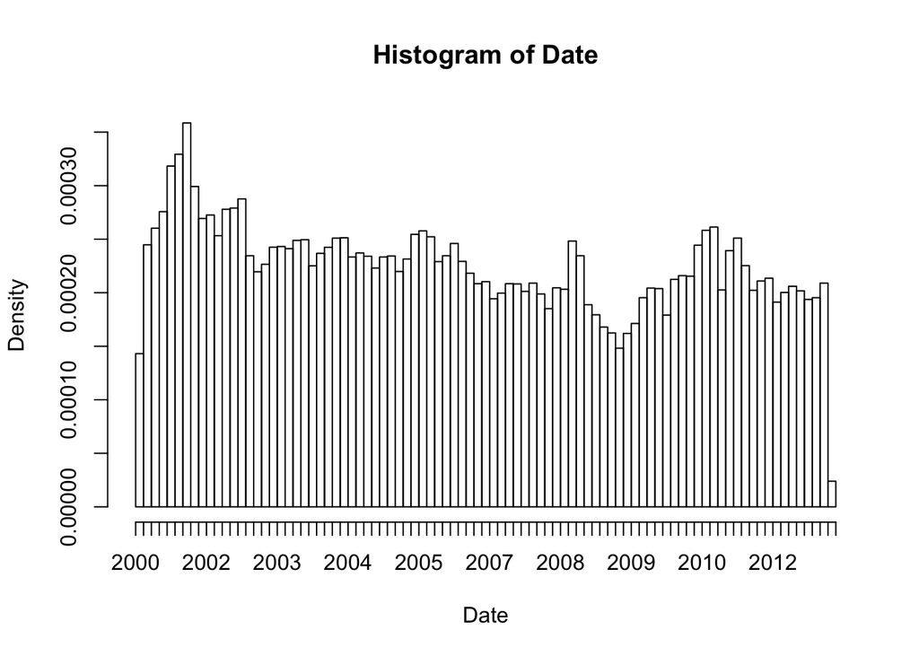

```r
hist(Date,breaks=100)
```

```r
table(Year)
```

```
## Year
##  2001  2002  2003  2004  2005  2006  2007  2008  2009  2010  2011  2012
## 20669 18753 16657 16862 16484 16098 14280 14445 12167 15497 15637 14092
```

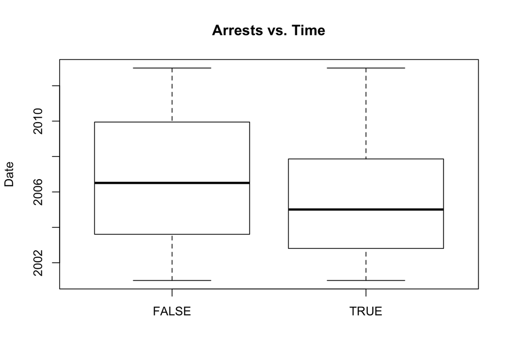

```r
boxplot(Date~Arrest,ylab="Date", main="Arrests vs. Time")
```

```r
#For what proportion of motor vehicle thefts in 2001 was an arrest made?
table(Arrest[Year==2001])
```

```
##
## FALSE  TRUE
## 18517  2152
```

```r
2152/(2152+18517)
```

```
## [1] 0.1041173
```

```r
#For what proportion of motor vehicle thefts in 2007 was an arrest made?
table(Arrest[Year==2007])
```

```
##
## FALSE  TRUE
## 13068  1212
```

```r
1212/(1212+13068)
```

```
## [1] 0.08487395
```

```r
#For what proportion of motor vehicle thefts in 2012 was an arrest made?
table(Arrest[Year==2012])
```

```
##
## FALSE  TRUE
## 13542   550
```

```r
550/(550+13542)
```

```
## [1] 0.03902924
```

- Problem 4 - Popular Locations

```r
sort(table(mvt$LocationDescription))
```

```
##
##     AIRPORT BUILDING NON-TERMINAL - SECURE AREA
##                                               1
##                  AIRPORT EXTERIOR - SECURE AREA
##                                               1
##                                 ANIMAL HOSPITAL
##                                               1
##                                 APPLIANCE STORE
##                                               1
##                                       CTA TRAIN
##                                               1
##                         JAIL / LOCK-UP FACILITY
##                                               1
##                                       NEWSSTAND
##                                               1
##                                          BRIDGE
##                                               2
##               COLLEGE/UNIVERSITY RESIDENCE HALL
##                                               2
##                               CURRENCY EXCHANGE
##                                               2
##                                   BOWLING ALLEY
##                                               3
##                                  CLEANING STORE
##                                               3
##                           MEDICAL/DENTAL OFFICE
##                                               3
##                              ABANDONED BUILDING
##                                               4
## AIRPORT BUILDING NON-TERMINAL - NON-SECURE AREA
##                                               4
##                                      BARBERSHOP
##                                               4
##                  LAKEFRONT/WATERFRONT/RIVERBANK
##                                               4
##                                         LIBRARY
##                                               4
##                                SAVINGS AND LOAN
##                                               4
##  AIRPORT TERMINAL UPPER LEVEL - NON-SECURE AREA
```

[output cut: 102 more lines]

```
##                                            1302
##                   RESIDENTIAL YARD (FRONT/BACK)
##                                            1536
##                          DRIVEWAY - RESIDENTIAL
##                                            1675
##                                     GAS STATION
##                                            2111
##                                           ALLEY
##                                            2308
##                                           OTHER
##                                            4573
##                  PARKING LOT/GARAGE(NON.RESID.)
##                                           14852
##                                          STREET
##                                          156564
```

```r
Top5<-subset(mvt,LocationDescription=="STREET"|LocationDescription=="PARKING LOT/GARAGE(NON.RESID.)"|LocationDescription=="ALLEY"|LocationDescription=="GAS STATION"|LocationDescription=="DRIVEWAY - RESIDENTIAL")
dim(Top5)
```

```
## [1] 177510     13
```

```r
Top5$LocationDescription = factor(Top5$LocationDescription)
#One of the locations has a much higher arrest rate than the other locations. Which is it?
ArrestRate <- table(Top5$LocationDescription,Top5$Arrest)
prop.table(ArrestRate,1)
```

```
##
##                                       FALSE       TRUE
##   ALLEY                          0.89211438 0.10788562
##   DRIVEWAY - RESIDENTIAL         0.92119403 0.07880597
##   GAS STATION                    0.79204169 0.20795831
##   PARKING LOT/GARAGE(NON.RESID.) 0.89206841 0.10793159
##   STREET                         0.92594083 0.07405917
```

```r
#On which day of the week do the most motor vehicle thefts at gas stations happen?
which.max(table(Top5$Weekday[Top5$LocationDescription=="GAS STATION"]))
```

```
## Saturday
##        3
```

```r
#On which day of the week do the fewest motor vehicle thefts in residential driveways happen?
which.min(table(Top5$Weekday[Top5$LocationDescription=="DRIVEWAY - RESIDENTIAL"]))
```

```
## Saturday
##        3
```

## Stock dynamics

A stock market is where buyers and sellers trade shares of a company, and is one of the most popular ways for individuals and companies to invest money. The size of the world stock market is now estimated to be in the trillions. The largest stock market in the world is the New York Stock Exchange (NYSE), located in New York City. About 2,800 companies are listed on the NSYE. In this problem, we’ll look at the monthly stock prices of five of these companies: IBM, General Electric (GE), Procter and Gamble, Coca Cola, and Boeing. The data used in this problem comes from Infochimps.

- Problem 1 - Summary Statistics

```r
IBM <- read.csv("IBMStock.csv")
GE <- read.csv("GEStock.csv")
ProcterGamble <- read.csv("ProcterGambleStock.csv")
CocaCola <- read.csv("CocaColaStock.csv")
Boeing <- read.csv("BoeingStock.csv")
str(IBM)
```

```
## 'data.frame':    480 obs. of  2 variables:
##  $ Date      : Factor w/ 480 levels "1/1/00","1/1/01",..: 11 171 211 251 291 331 371 411 451 51 ...
##  $ StockPrice: num  360 347 327 320 270 ...
```

```r
View(IBM)
IBM$Date = as.Date(IBM$Date,"%m/%d/%y")
GE$Date = as.Date(GE$Date,"%m/%d/%y")
ProcterGamble$Date = as.Date(ProcterGamble$Date,"%m/%d/%y")
CocaCola$Date = as.Date(CocaCola$Date,"%m/%d/%y")
Boeing$Date = as.Date(Boeing$Date,"%m/%d/%y")
min(IBM$Date,GE$Date,ProcterGamble$Date,CocaCola$Date,Boeing$Date)
```

```
## [1] "1970-01-01"
```

```r
max(IBM$Date,GE$Date,ProcterGamble$Date,CocaCola$Date,Boeing$Date)
```

```
## [1] "2009-12-01"
```

```r
mean(IBM$StockPrice)
```

```
## [1] 144.375
```

```r
min(GE$StockPrice)
```

```
## [1] 9.293636
```

```r
max(CocaCola$StockPrice)
```

```
## [1] 146.5843
```

```r
summary(Boeing$StockPrice)
```

```
##    Min. 1st Qu.  Median    Mean 3rd Qu.    Max.
##   12.74   34.64   44.88   46.59   57.21  107.30
```

```r
sd(ProcterGamble$StockPrice)
```

```
## [1] 18.19414
```

- Problem 2 - Visualizing Stock Dynamics

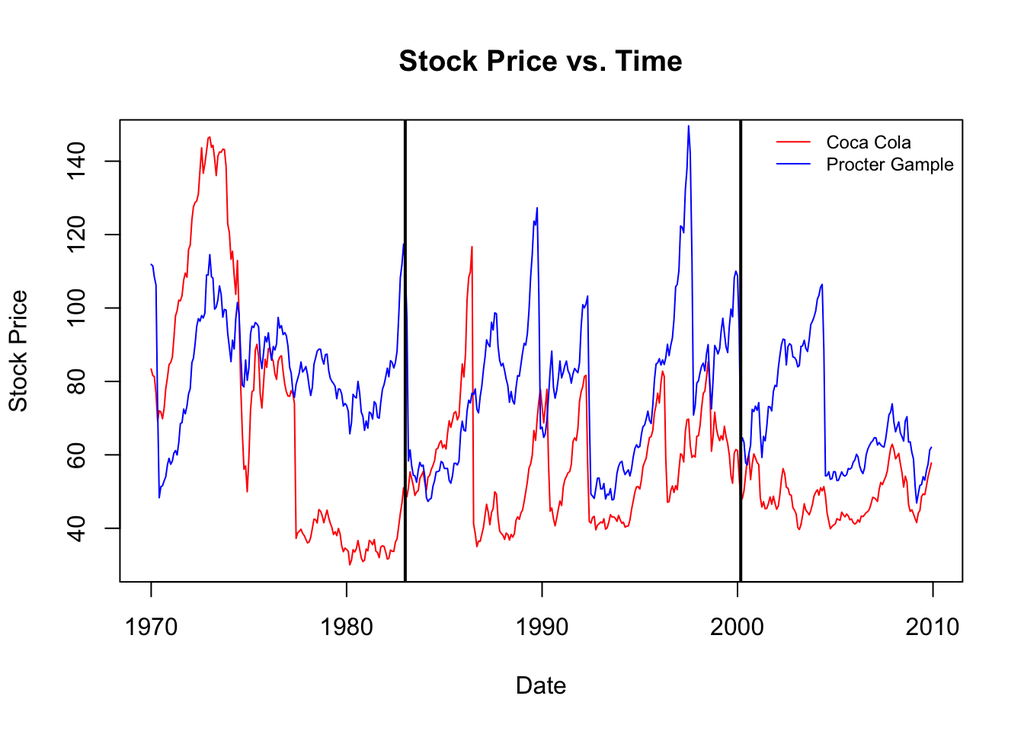

```r
plot(CocaCola$Date,CocaCola$StockPrice,type="l",xlab = "Date", ylab = "Stock Price", main = "Stock Price vs. Time",col="red")
lines(ProcterGamble$Date,ProcterGamble$StockPrice,col="blue",type="l")
legend('topright', c("Coca Cola","Procter Gample"), lty=1, col=c('red', 'blue'), bty='n', cex=.75)
#In March of 2000, the technology bubble burst, and a stock market crash occurred. According to this plot, which company's stock dropped more?
abline(v=as.Date(c("2000-03-01")),lwd=2)
#Around 1983, the stock for one of these companies (Coca-Cola or Procter and Gamble) was going up, while the other was going down. Which one was going up?
#In the time period shown in the plot, which stock generally has lower values?
abline(v=as.Date(c("1983-01-01")),lwd=2)
```

* Problem 3 - Visualizing Stock Dynamics 1995-2005

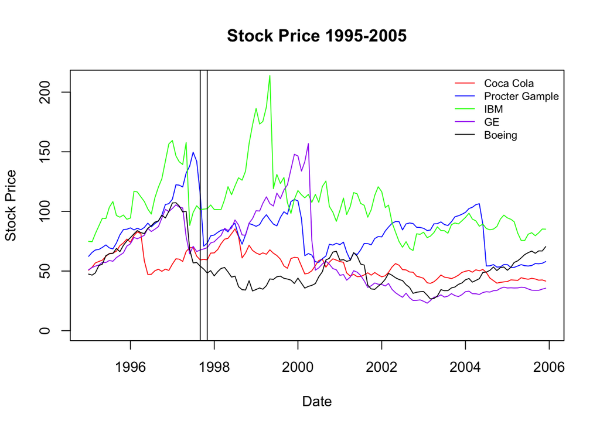

```r
plot(CocaCola$Date[301:432], CocaCola$StockPrice[301:432], type="l", col="red", ylim=c(0,210),xlab='Date',ylab='Stock Price', main = 'Stock Price 1995-2005')
lines(ProcterGamble$Date[301:432],ProcterGamble$StockPrice[301:432],col="blue",type="l",ylim=c(0,210))
lines(IBM$Date[301:432],IBM$StockPrice[301:432],col="green",type="l",ylim=c(0,210))
lines(GE$Date[301:432],GE$StockPrice[301:432],col="purple",type="l",ylim=c(0,210))
lines(Boeing$Date[301:432],Boeing$StockPrice[301:432],col="black",type="l",ylim=c(0,210))
legend('topright', c("Coca Cola","Procter Gample","IBM","GE","Boeing"), lty=1, col=c('red', 'blue','green','purple','black'), bty='n', cex=.75)
abline(v=as.Date(c("1997-09-01","1997-11-01")))
```

* Problem 4 - Monthly Trends

```r
#In which months has IBM historically had a higher stock price (on average)?
tapply(IBM$StockPrice,months(IBM$Date),mean) > mean(IBM$StockPrice)
```

```
##     April    August  December  February   January      July      June
##      TRUE     FALSE     FALSE      TRUE      TRUE     FALSE     FALSE
##     March       May  November   October September
##      TRUE      TRUE     FALSE     FALSE     FALSE
```

```r
# General Electric and Coca-Cola both have their highest average stock price in the same month. Which month is this?
which.max(tapply(CocaCola$StockPrice,months(CocaCola$Date),mean))
```

```
## April
##     1
```

```r
which.max(tapply(GE$StockPrice,months(GE$Date),mean))
```

```
## April
##     1
```

```r
tapply(ProcterGamble$StockPrice,months(ProcterGamble$Date),mean)
```

```
##     April    August  December  February   January      July      June
##  77.68671  76.82266  78.29661  79.02575  79.61798  76.64556  77.39275
##     March       May  November   October September
##  77.34761  77.85958  78.45610  76.67903  76.62385
```

```r
tapply(Boeing$StockPrice,months(Boeing$Date),mean)
```

```
##     April    August  December  February   January      July      June
##  47.04686  46.86311  46.17315  46.89223  46.51097  46.55360  47.38525
##     March       May  November   October September
##  46.88208  48.13716  45.14990  45.21603  46.30485
```

## demographics and employment in the united states

- Problem 1 - Loading and Summarizing the Dataset

```r
CPS <- read.csv("CPSData.csv")
str(CPS)
```

```
## 'data.frame':    131302 obs. of  14 variables:
##  $ PeopleInHousehold : int  1 3 3 3 3 3 3 2 2 2 ...
##  $ Region            : Factor w/ 4 levels "Midwest","Northeast",..: 3 3 3 3 3 3 3 3 3 3 ...
##  $ State             : Factor w/ 51 levels "Alabama","Alaska",..: 1 1 1 1 1 1 1 1 1 1 ...
##  $ MetroAreaCode     : int  26620 13820 13820 13820 26620 26620 26620 33660 33660 26620 ...
##  $ Age               : int  85 21 37 18 52 24 26 71 43 52 ...
##  $ Married           : Factor w/ 5 levels "Divorced","Married",..: 5 3 3 3 5 3 3 1 1 3 ...
##  $ Sex               : Factor w/ 2 levels "Female","Male": 1 2 1 2 1 2 2 1 2 2 ...
##  $ Education         : Factor w/ 8 levels "Associate degree",..: 1 4 4 6 1 2 4 4 4 2 ...
##  $ Race              : Factor w/ 6 levels "American Indian",..: 6 3 3 3 6 6 6 6 6 6 ...
##  $ Hispanic          : int  0 0 0 0 0 0 0 0 0 0 ...
##  $ CountryOfBirthCode: int  57 57 57 57 57 57 57 57 57 57 ...
##  $ Citizenship       : Factor w/ 3 levels "Citizen, Native",..: 1 1 1 1 1 1 1 1 1 1 ...
##  $ EmploymentStatus  : Factor w/ 5 levels "Disabled","Employed",..: 4 5 1 3 2 2 2 2 3 2 ...
##  $ Industry          : Factor w/ 14 levels "Agriculture, forestry, fishing, and hunting",..: NA 11 NA NA 11 4 14 4 NA 12 ...
```

```r
#Among the interviewees with a value reported for the Industry variable, what is the most common industry of employment?
which.max(table(CPS$Industry))
```

```
## Educational and health services
##                               4
```

```r
#Which state has the fewest interviewees?
which.min(table(CPS$State))
```

```
## New Mexico
##         32
```

```r
#Which state has the largest number of interviewees?
which.max(table(CPS$State))
```

```
## California
##          5
```

```r
#What proportion of interviewees are citizens of the United States?
table(CPS$Citizenship)
```

```
##
##      Citizen, Native Citizen, Naturalized          Non-Citizen
##               116639                 7073                 7590
```

```r
(7073+116639)/131302
```

```
## [1] 0.9421943
```

```r
#For which races are there at least 250 interviewees in the CPS dataset of Hispanic ethnicity?
table(CPS$Race,CPS$Hispanic)
```

```
##
##                        0     1
##   American Indian   1129   304
##   Asian             6407   113
##   Black            13292   621
##   Multiracial       2449   448
##   Pacific Islander   541    77
##   White            89190 16731
```

- Problem 2 - Evaluating Missing Values

```r
names(CPS)
```

```
##  [1] "PeopleInHousehold"  "Region"             "State"
##  [4] "MetroAreaCode"      "Age"                "Married"
##  [7] "Sex"                "Education"          "Race"
## [10] "Hispanic"           "CountryOfBirthCode" "Citizenship"
## [13] "EmploymentStatus"   "Industry"
```

```r
any(sapply(CPS$PeopleInHousehold,is.na))
```

```
## [1] FALSE
```

```r
any(sapply(CPS$Region,is.na))
```

```
## [1] FALSE
```

```r
any(sapply(CPS$State,is.na))
```

```
## [1] FALSE
```

```r
any(sapply(CPS$MetroAreaCode,is.na))
```

```
## [1] TRUE
```

```r
any(sapply(CPS$Age,is.na))
```

```
## [1] FALSE
```

```r
any(sapply(CPS$Married,is.na))
```

```
## [1] TRUE
```

```r
any(sapply(CPS$Sex,is.na))
```

```
## [1] FALSE
```

```r
any(sapply(CPS$Education,is.na))
```

```
## [1] TRUE
```

```r
any(sapply(CPS$Race,is.na))
```

```
## [1] FALSE
```

```r
any(sapply(CPS$Hispanic,is.na))
```

```
## [1] FALSE
```

```r
any(sapply(CPS$CountryOfBirthCode,is.na))
```

```
## [1] FALSE
```

```r
any(sapply(CPS$Citizenship,is.na))
```

```
## [1] FALSE
```

```r
any(sapply(CPS$EmploymentStatus,is.na))
```

```
## [1] TRUE
```

```r
any(sapply(CPS$Industry,is.na))
```

```
## [1] TRUE
```

```r
#We will try to determine if there is a pattern in the missing values of the Married variable
m = table(is.na(CPS$Married))
prop.table(m)
```

```
##
##    FALSE     TRUE
## 0.807025 0.192975
```

```r
prop.table(table(CPS$Region,is.na(CPS$Married)),1)
```

```
##
##                 FALSE      TRUE
##   Midwest   0.8020141 0.1979859
##   Northeast 0.8262462 0.1737538
##   South     0.8080333 0.1919667
##   West      0.7953703 0.2046297
```

```r
prop.table(table(CPS$Sex,is.na(CPS$Married)),1)
```

```
##
##              FALSE      TRUE
##   Female 0.8189564 0.1810436
##   Male   0.7944094 0.2055906
```

```r
prop.table(table(CPS$Age,is.na(CPS$Married)),1)
```

```
##
##      FALSE TRUE
##   0      0    1
##   1      0    1
##   2      0    1
##   3      0    1
##   4      0    1
##   5      0    1
##   6      0    1
##   7      0    1
##   8      0    1
##   9      0    1
##   10     0    1
##   11     0    1
##   12     0    1
```

[output cut: 69 more lines]

```r
prop.table(table(CPS$Citizenship,is.na(CPS$Married)),1)
```

```
##
##                             FALSE       TRUE
##   Citizen, Native      0.78838124 0.21161876
##   Citizen, Naturalized 0.97695462 0.02304538
##   Non-Citizen          0.93517787 0.06482213
```

```r
#How many states had all interviewees living in a non-metropolitan area (aka they have a missing MetroAreaCode value)?
table(CPS$State,is.na(CPS$MetroAreaCode))
```

```
##
##                        FALSE  TRUE
##   Alabama               1020   356
##   Alaska                   0  1590
##   Arizona               1327   201
##   Arkansas               724   697
##   California           11333   237
##   Colorado              2545   380
##   Connecticut           2593   243
##   Delaware              1696   518
##   District of Columbia  1791     0
##   Florida               4947   202
##   Georgia               2250   557
##   Hawaii                1576   523
##   Idaho                  761   757
##   Illinois              3473   439
##   Indiana               1420   584
##   Iowa                  1297  1231
##   Kansas                1234   701
##   Kentucky               908   933
##   Louisiana             1216   234
##   Maine                  909  1354
##   Maryland              2978   222
##   Massachusetts         1858   129
##   Michigan              2517   546
##   Minnesota             2150   989
##   Mississippi            376   854
##   Missouri              1440   705
##   Montana                199  1015
##   Nebraska               816  1133
##   Nevada                1609   247
##   New Hampshire         1148  1514
##   New Jersey            2567     0
##   New Mexico             832   270
##   New York              5144   451
##   North Carolina        1642   977
##   North Dakota           432  1213
##   Ohio                  2754   924
##   Oklahoma              1024   499
##   Oregon                1519   424
##   Pennsylvania          3245   685
##   Rhode Island          2209     0
##   South Carolina        1139   519
##   South Dakota           595  1405
##   Tennessee             1149   635
##   Texas                 6060  1017
##   Utah                  1455   387
##   Vermont                657  1233
##   Virginia              2367   586
##   Washington            1937   429
##   West Virginia          344  1065
##   Wisconsin             1882   804
##   Wyoming                  0  1624
```

```r
#Which region of the United States has the largest proportion of interviewees living in a non-metropolitan area?
prop.table(table(CPS$Region,is.na(CPS$MetroAreaCode)),1)
```

```
##
##                 FALSE      TRUE
##   Midwest   0.6521314 0.3478686
##   Northeast 0.7837619 0.2162381
##   South     0.7621560 0.2378440
##   West      0.7563372 0.2436628
```

```r
#Which state has a proportion of interviewees living in a non-metropolitan area closest to 30%?
#Which state has the largest proportion of non-metropolitan interviewees,
prop.table(table(CPS$State,is.na(CPS$MetroAreaCode)),1)
```

```
##
##                             FALSE       TRUE
##   Alabama              0.74127907 0.25872093
##   Alaska               0.00000000 1.00000000
##   Arizona              0.86845550 0.13154450
##   Arkansas             0.50950035 0.49049965
##   California           0.97951599 0.02048401
##   Colorado             0.87008547 0.12991453
##   Connecticut          0.91431594 0.08568406
##   Delaware             0.76603433 0.23396567
##   District of Columbia 1.00000000 0.00000000
##   Florida              0.96076908 0.03923092
##   Georgia              0.80156751 0.19843249
##   Hawaii               0.75083373 0.24916627
##   Idaho                0.50131752 0.49868248
##   Illinois             0.88778119 0.11221881
##   Indiana              0.70858283 0.29141717
##   Iowa                 0.51305380 0.48694620
##   Kansas               0.63772610 0.36227390
##   Kentucky             0.49321021 0.50678979
##   Louisiana            0.83862069 0.16137931
##   Maine                0.40167919 0.59832081
##   Maryland             0.93062500 0.06937500
##   Massachusetts        0.93507801 0.06492199
##   Michigan             0.82174339 0.17825661
##   Minnesota            0.68493151 0.31506849
##   Mississippi          0.30569106 0.69430894
##   Missouri             0.67132867 0.32867133
##   Montana              0.16392092 0.83607908
##   Nebraska             0.41867624 0.58132376
##   Nevada               0.86691810 0.13308190
##   New Hampshire        0.43125470 0.56874530
##   New Jersey           1.00000000 0.00000000
##   New Mexico           0.75499093 0.24500907
##   New York             0.91939231 0.08060769
##   North Carolina       0.62695685 0.37304315
##   North Dakota         0.26261398 0.73738602
##   Ohio                 0.74877651 0.25122349
##   Oklahoma             0.67235719 0.32764281
##   Oregon               0.78178075 0.21821925
##   Pennsylvania         0.82569975 0.17430025
##   Rhode Island         1.00000000 0.00000000
##   South Carolina       0.68697226 0.31302774
##   South Dakota         0.29750000 0.70250000
##   Tennessee            0.64405830 0.35594170
##   Texas                0.85629504 0.14370496
##   Utah                 0.78990228 0.21009772
##   Vermont              0.34761905 0.65238095
##   Virginia             0.80155774 0.19844226
##   Washington           0.81868132 0.18131868
##   West Virginia        0.24414478 0.75585522
##   Wisconsin            0.70067014 0.29932986
##   Wyoming              0.00000000 1.00000000
```

- Problem 3 - Integrating Metropolitan Area Data

```r
MetroAreaMap<-read.csv("MetroAreaCodes.csv")
CountryMap<-read.csv("CountryCodes.csv")
dim(MetroAreaMap)
```

```
## [1] 271   2
```

```r
dim(CountryMap)
```

```
## [1] 149   2
```

```r
CPS = merge(CPS, MetroAreaMap, by.x="MetroAreaCode", by.y="Code", all.x=TRUE)
str(CPS)
```

```
## 'data.frame':    131302 obs. of  15 variables:
##  $ MetroAreaCode     : int  10420 10420 10420 10420 10420 10420 10420 10420 10420 10420 ...
##  $ PeopleInHousehold : int  4 4 2 4 1 3 4 4 2 3 ...
##  $ Region            : Factor w/ 4 levels "Midwest","Northeast",..: 1 1 1 1 1 1 1 1 1 1 ...
##  $ State             : Factor w/ 51 levels "Alabama","Alaska",..: 36 36 36 36 36 36 36 36 36 36 ...
##  $ Age               : int  2 9 73 40 63 19 30 6 60 32 ...
##  $ Married           : Factor w/ 5 levels "Divorced","Married",..: NA NA 2 2 3 3 2 NA 2 2 ...
##  $ Sex               : Factor w/ 2 levels "Female","Male": 2 2 1 1 2 1 1 1 1 2 ...
##  $ Education         : Factor w/ 8 levels "Associate degree",..: NA NA 8 4 6 4 2 NA 4 4 ...
##  $ Race              : Factor w/ 6 levels "American Indian",..: 6 6 6 6 6 6 2 6 6 6 ...
##  $ Hispanic          : int  0 0 0 0 0 0 0 1 0 0 ...
##  $ CountryOfBirthCode: int  57 57 57 362 57 57 203 57 57 57 ...
##  $ Citizenship       : Factor w/ 3 levels "Citizen, Native",..: 1 1 1 2 1 1 3 1 1 1 ...
##  $ EmploymentStatus  : Factor w/ 5 levels "Disabled","Employed",..: NA NA 4 3 1 2 3 NA 2 2 ...
##  $ Industry          : Factor w/ 14 levels "Agriculture, forestry, fishing, and hunting",..: NA NA NA NA NA 7 NA NA 4 13 ...
##  $ MetroArea         : Factor w/ 271 levels "Akron, OH","Albany-Schenectady-Troy, NY",..: 1 1 1 1 1 1 1 1 1 1 ...
```

```r
#How many interviewees have a missing value for the new MetroArea variable?
table(is.na(CPS$MetroArea))
```

```
##
## FALSE  TRUE
## 97064 34238
```

```r
#Which of the following metropolitan areas has the largest number of interviewees?
sort(table(CPS$MetroArea))
```

```
##
##                        Appleton-Oshkosh-Neenah, WI
##                                                  0
##                  Grand Rapids-Muskegon-Holland, MI
##                                                  0
##                Greenville-Spartanburg-Anderson, SC
##                                                  0
##                        Hinesville-Fort Stewart, GA
##                                                  0
##                                      Jamestown, NY
##                                                  0
##                         Kalamazoo-Battle Creek, MI
##                                                  0
##                        Portsmouth-Rochester, NH-ME
##                                                  0
##                                  Bowling Green, KY
##                                                 29
##                                     Ocean City, NJ
##                                                 30
##                                    Springfield, OH
##                                                 34
##                              Bloomington-Normal IL
##                                                 40
##                                       Valdosta, GA
##                                                 42
##                                  Warner Robins, GA
##                                                 42
##                                    Tallahassee, FL
##                                                 43
##                                       Columbia, MO
##                                                 47
##                                    Punta Gorda, FL
##                                                 48
##                                        Midland, TX
##                                                 51
##                            Niles-Benton Harbor, MI
##                                                 51
##                                   Johnson City, TN
##                                                 52
##                                       Santa Fe, NM
```

[output cut: 488 more lines]

```
##                                               1942
##                     Boston-Cambridge-Quincy, MA-NH
##                                               2229
##               Providence-Fall River-Warwick, MA-RI
##                                               2284
##                Chicago-Naperville-Joliet, IN-IN-WI
##                                               2772
##           Philadelphia-Camden-Wilmington, PA-NJ-DE
##                                               2855
##               Los Angeles-Long Beach-Santa Ana, CA
##                                               4102
##       Washington-Arlington-Alexandria, DC-VA-MD-WV
##                                               4177
## New York-Northern New Jersey-Long Island, NY-NJ-PA
##                                               5409
```

```r
#Which metropolitan area has the highest proportion of interviewees of Hispanic ethnicity?
sort(tapply(CPS$Hispanic,CPS$MetroArea,mean))
```

```
##                                       Anderson, SC
##                                        0.000000000
##                                      Ann Arbor, MI
##                                        0.000000000
##                                Barnstable Town, MA
##                                        0.000000000
##                              Bloomington-Normal IL
##                                        0.000000000
##                                    Bloomington, IN
##                                        0.000000000
##                                  Bowling Green, KY
##                                        0.000000000
##                                        Decatur, IL
##                                        0.000000000
##                                     Eau Claire, WI
##                                        0.000000000
##                                       Florence, AL
##                                        0.000000000
##                      Hagerstown-Martinsburg, MD-WV
##                                        0.000000000
##                                   Harrisonburg, VA
##                                        0.000000000
##                       Huntington-Ashland, WV-KY-OH
##                                        0.000000000
##                                     Huntsville, AL
##                                        0.000000000
##                                        Jackson, MI
##                                        0.000000000
##                                      Johnstown, PA
##                                        0.000000000
##                                          Macon, GA
##                                        0.000000000
##                                         Mobile, AL
##                                        0.000000000
##                                      Salisbury, MD
##                                        0.000000000
##                                       Savannah, GA
##                                        0.000000000
##                                  Warner Robins, GA
##                                        0.000000000
```

[output cut: 473 more lines]

```
##                                        0.606060606
##                                         Madera, CA
##                                        0.614035088
##                                    San Antonio, TX
##                                        0.644151565
##                                      El Centro, CA
##                                        0.686868687
##                                        El Paso, TX
##                                        0.790983607
##                          Brownsville-Harlingen, TX
##                                        0.797468354
##                         McAllen-Edinburg-Pharr, TX
##                                        0.948717949
##                                         Laredo, TX
##                                        0.966292135
```

```r
#determine the number of metropolitan areas in the United States from which at least 20% of interviewees are Asian.
table(tapply(CPS$Race=="Asian",CPS$MetroArea,mean)>0.2)
```

```
##
## FALSE  TRUE
##   260     4
```

```r
#determine which metropolitan area has the smallest proportion of interviewees who have received no high school diploma.
which.min(tapply(CPS$Education == "No high school diploma", CPS$MetroArea, mean, na.rm=TRUE))
```

```
## Iowa City, IA
##           112
```

- Problem 4.1 - Integrating Country of Birth Data

```r
CPS = merge(CPS, CountryMap, by.x="CountryOfBirthCode", by.y="Code", all.x=TRUE)
#How many interviewees have a missing value for the new country of birth variable?
table(is.na(CPS$Country))
```

```
##
##  FALSE   TRUE
## 131126    176
```

```r
#Among all interviewees born outside of North America, which country was the most common place of birth?
sort(table(CPS$Country))
```

```
##
##                         Cyprus                         Kosovo
##                              0                              0
##         Oceania, not specified       Other U. S. Island Areas
##                              0                              0
##                          Wales               Northern Ireland
##                              0                              2
##                       Tanzania                     Azerbaijan
##                              2                              3
##                 Czechoslovakia               St. Kitts--Nevis
##                              3                              3
##                        Georgia                       Barbados
##                              5                              6
##                        Denmark                         Latvia
##                              6                              6
##                          Samoa                        Senegal
##                              6                              6
##                      Singapore                       Slovakia
##                              6                              6
##                          Tonga                       Zimbabwe
##                              6                              6
##   South America, not specified                      St. Lucia
##                              7                              7
##                        Algeria        Americas, not specified
##                              9                              9
##                         Belize                           Fiji
##                              9                              9
## St. Vincent and the Grenadines                        Bahamas
##                              9                             10
##                        Finland                         Kuwait
##                             10                             10
##                      Lithuania                 Czech Republic
##                             10                             11
##                       Dominica                       Paraguay
##                             11                             11
##                        Croatia                      Macedonia
##                             12                             12
##                        Moldova            Antigua and Barbuda
##                             12                             13
##                        Belgium                        Bermuda
```

[output cut: 96 more lines]

```
##                            217                            309
##             Dominican Republic                          Korea
##                            330                            334
##                         Canada                           Cuba
##                            410                            426
##                        Germany                        Vietnam
##                            438                            458
##                    El Salvador                    Puerto Rico
##                            477                            518
##                          China                          India
##                            581                            770
##                    Philippines                         Mexico
##                            839                           3921
##                  United States
##                         115063
```

```r
# What proportion of the interviewees from the "New York-Northern New Jersey-Long Island, NY-NJ-PA" metropolitan area have a country of birth that is not the United States?
sort(prop.table(table(CPS$Country[CPS$MetroArea=="New York-Northern New Jersey-Long Island, NY-NJ-PA"])))
```

```
##
##                    Afghanistan                        Albania
##                   0.0000000000                   0.0000000000
##                        Algeria                     Azerbaijan
##                   0.0000000000                   0.0000000000
##                         Azores                        Bahamas
##                   0.0000000000                   0.0000000000
##                        Belgium                         Belize
##                   0.0000000000                   0.0000000000
##           Bosnia & Herzegovina                       Bulgaria
##                   0.0000000000                   0.0000000000
##                       Cambodia                       Cameroon
##                   0.0000000000                   0.0000000000
##                     Cape Verde                         Cyprus
##                   0.0000000000                   0.0000000000
##                 Czech Republic                 Czechoslovakia
##                   0.0000000000                   0.0000000000
##                        Denmark                        Eritrea
##                   0.0000000000                   0.0000000000
##                           Fiji                        Georgia
##                   0.0000000000                   0.0000000000
##                           Guam                      Indonesia
##                   0.0000000000                   0.0000000000
##                           Iraq                         Kosovo
##                   0.0000000000                   0.0000000000
##                         Kuwait                           Laos
##                   0.0000000000                   0.0000000000
##                         Latvia                      Lithuania
##                   0.0000000000                   0.0000000000
##               Northern Ireland         Oceania, not specified
##                   0.0000000000                   0.0000000000
##       Other U. S. Island Areas                          Samoa
##                   0.0000000000                   0.0000000000
##                       Scotland                   Sierra Leone
##                   0.0000000000                   0.0000000000
##                      Singapore                       Slovakia
##                   0.0000000000                   0.0000000000
##                        Somalia                      St. Lucia
##                   0.0000000000                   0.0000000000
##                          Sudan                    Switzerland
```

[output cut: 96 more lines]

```
##                   0.0072168764                   0.0075869726
##                         Russia                       Columbia
##                   0.0079570688                   0.0081421170
##                          Haiti                    El Salvador
##                   0.0083271651                   0.0085122132
##                         Mexico                         Guyana
##                   0.0125832717                   0.0127683198
##                        Jamaica                        Ecuador
##                   0.0135085122                   0.0146188009
##                    Puerto Rico                          India
##                   0.0175795707                   0.0177646188
##                          China             Dominican Republic
##                   0.0194300518                   0.0334937084
##                  United States
##                   0.6913397483
```

```r
1-0.6913397483
```

```
## [1] 0.3086603
```

```r
#Which metropolitan area has the largest number (note -- not proportion) of interviewees with a country of birth in India, Brazil, and Somalia?
which.max(prop.table(table(CPS$MetroArea[CPS$Country=="India"])))
```

```
## New York-Northern New Jersey-Long Island, NY-NJ-PA
##                                                173
```

```r
which.max(prop.table(table(CPS$MetroArea[CPS$Country=="Brazil"])))
```

```
## Boston-Cambridge-Quincy, MA-NH
##                             34
```

```r
which.max(prop.table(table(CPS$MetroArea[CPS$Country=="Somalia"])))
```

```
## Minneapolis-St Paul-Bloomington, MN-WI
##                                    160
```